# BUS 4440 Project_CDC

C. Krance

2026-05-29

Coronary heart disease (CHD) is the leading cause of death in the United States, accounting for approximately 375,000 deaths annually. Despite its prevalence, CHD remains significantly underdiagnosed, particularly among populations with limited healthcare access, creating opportunities for data-driven screening tools that can identify high-risk individuals before a clinical event occurs. Early and accurate classification of CHD risk has direct applications in preventive care, patient stratification for clinical trial enrollment, and targeted pharmaceutical intervention.

This project uses data from the 2024 Behavioral Risk Factor Surveillance System (BRFSS), an annual CDC telephone survey collecting health-related behavioral and chronic condition data from over 400,000 U.S. adults. The BRFSS is one of the largest continuously conducted health surveys in the world and serves as a primary data source for population-level disease surveillance. Variables were selected to capture three domains known to be associated with CHD risk: lifestyle behaviors (smoking, physical activity, alcohol consumption), chronic condition history (diabetes, stroke), and demographic characteristics (age, sex, race, BMI, income, education).

Three classification models (decision tree, logistic regression, and XGBoost) were trained and evaluated on a downsampled, balanced dataset to address the natural class imbalance in CHD prevalence. LASSO regularization was applied for variable selection prior to model training. Models were evaluated on a held-out validation set using sensitivity, specificity, and AUC as primary performance metrics, with sensitivity prioritized given the clinical cost asymmetry between false negatives and false positives in a medical screening context.

### Hypothesis

This project examines whether demographic, lifestyle, and chronic condition variables from the 2024 BRFSS can accurately classify coronary heart disease status. I hypothesize that logistic regression and ensemble models trained on these variables will achieve AUC above 0.80, with age, stroke history, and self-reported general health emerging as the strongest predictors.

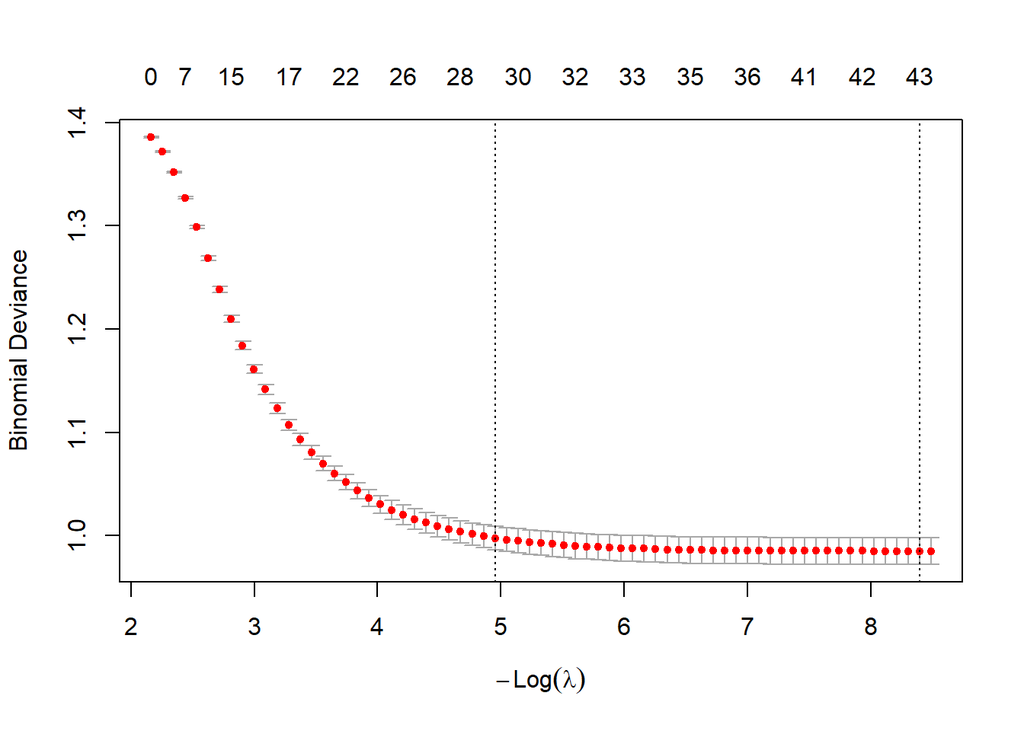

Variables with the largest absolute effect were kept in the final dataset. 9 Explanatory variables performed nearly identically to all 16 variables.

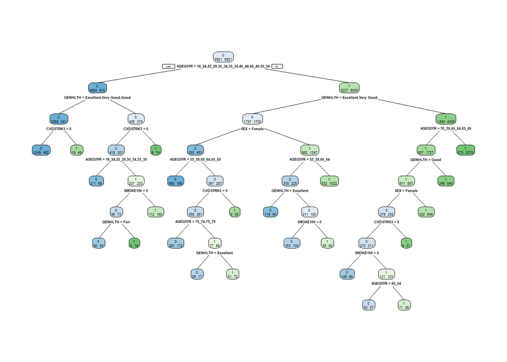

### Decision Tree

The tree visualizes that age and self-rated general health are the two strongest predictors of CHD, followed by stroke history and sex. The highest-risk profile is an older adult (55+, more prevalent in men) who rates their health as Fair or Poor and has a prior stroke history.

| Metric | Value |
| --- | --- |
| Accuracy | 75.66% |
| Sensitivity | 81.34% |
| Specificity | 69.98% |
| PPV | 73.04% |
| NPV | 78.95% |
| AUC | 0.810 |

The model achieves the highest sensitivity of the three models, correctly identifying 81.34% of true CHD cases. McNemar’s test (p < 2.2e-16) confirms significantly more false positives than false negatives (1,385 vs. 861) — a clinically acceptable asymmetry, as over-flagging CHD risk is preferable to missing true cases. Performance is significantly better than random guessing (p < 2.2e-16).

### Logistic Regression

Age is the strongest predictor of CHD. Coefficients become positive and statistically significant beginning at ages 40–44 and increase monotonically through the 80+ group (β = 3.27, p < 0.001). Younger age groups were not statistically significant. Self-reported general health shows a strong dose-response pattern — Fair (β = 1.81) and Poor (β = 2.21) health carry the largest effects, though even “Very Good” and “Good” categories are positive and significant, suggesting CHD risk increases continuously as health declines.

Stroke history (β = 1.36, p < 0.001) is among the largest individual predictors, consistent with shared vascular pathology. Female sex (β = −0.82, p < 0.001) and Asian race (β = −0.72, p < 0.001) are negatively associated with CHD; most other race categories were not statistically significant. Time since last checkup shows an inverse relationship — individuals with checkups 2+ years ago have lower observed CHD odds (β = −0.70 for 5+ years, p < 0.001), though this likely reflects behavioral selection rather than a causal effect. Diabetes, cost barriers to care, and smoking are each positive and significant (p < 0.001).

| Metric | Value |
| --- | --- |
| Accuracy | 76.11% |
| Sensitivity | 78.11% |
| Specificity | 74.10% |
| PPV | 75.10% |
| NPV | 77.20% |
| AUC | 0.839 |

Five-fold cross-validation produced a consistent accuracy of 76.42%, indicating the model generalizes well and is not overfit. McNemar’s test (p < 0.001) confirms significantly more false positives than false negatives (1,195 vs. 1,010) — a clinically acceptable asymmetry for a screening application. Performance is significantly better than random guessing (p < 2.2e-16).

### XGBoost

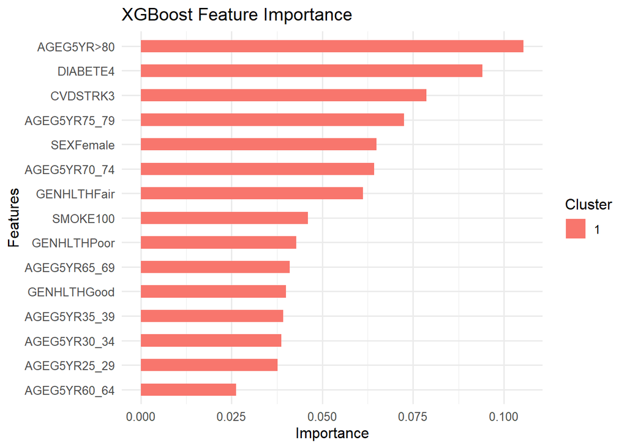

The XGBoost feature importance plot confirms the patterns identified by logistic regression and LASSO: the 80+ age group is the single most important feature, followed by diabetes, stroke history, and older age brackets. Female sex, declining general health, and smoking round out the top predictors. The close alignment between XGBoost and logistic regression variable importance provides independent validation that these relationships are robust and not model-specific artifacts.

| Metric | Value |
| --- | --- |
| Accuracy | 75.88% |
| Sensitivity | 78.93% |
| Specificity | 72.82% |
| PPV | 74.39% |
| NPV | 77.56% |
| AUC | 0.838 |

The model was trained with early stopping (20 rounds) and regularization via subsampling and column sampling to prevent overfitting. McNemar’s test (p < 2.587e-09) confirms significantly more false positives than false negatives (1,254 vs. 972) — consistent with the other models and clinically acceptable for a screening context. The marginal performance gap between XGBoost and logistic regression (ΔAUC = 0.001) suggests the underlying predictor relationships in this dataset are largely linear and well-captured by the simpler model. Performance is significantly better than random guessing (p < 2.2e-16).

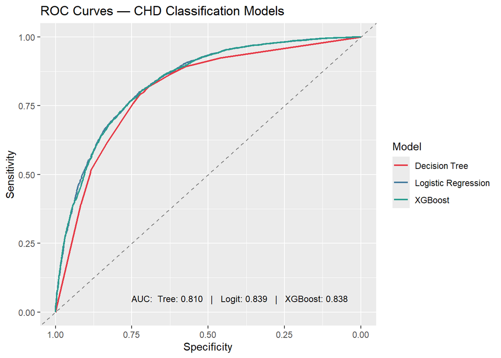

Model Performance Comparison

| Model | Accuracy | Sensitivity | Specificity | Pos_Pred_Value | Neg_Pred_Value | Kappa | AUC |
| --- | --- | --- | --- | --- | --- | --- | --- |
| Decision Tree | 0.7566 | 0.8134 | 0.6998 | 0.7304 | 0.7895 | 0.5132 | 0.810 |
| Logistic Regression | 0.7611 | 0.7811 | 0.7410 | 0.7510 | 0.7720 | 0.5221 | 0.839 |
| XGBoost | 0.7588 | 0.7893 | 0.7282 | 0.7439 | 0.7756 | 0.5176 | 0.838 |

The ROC curves confirm that logistic regression is the best-performing model, achieving the highest AUC of 0.839, followed closely by XGBoost (0.838) and the decision tree (0.810). AUC evaluates model performance across all possible classification thresholds simultaneously, making it a more reliable basis for model comparison than single-threshold metrics like sensitivity or accuracy alone.

While the decision tree achieved the highest sensitivity (81.34%) at the default 0.50 threshold, the ROC curve reveals this was partly an artifact of that threshold rather than superior overall discrimination. At any fixed operating point on the curve, logistic regression outperforms the decision tree while generating fewer false alarms.

Logistic regression was selected as the final model. It achieves the highest AUC, produces fully interpretable coefficients that map directly to known clinical risk factors, and matches XGBoost performance without the added complexity — confirming that on structured survey data of this type, a well-specified logistic regression is competitive with ensemble methods. All three models substantially outperform the no-information baseline (AUC = 0.50), and results are consistent with published CHD risk models such as the Framingham Heart Score, which achieves AUC in the 0.75–0.85 range on comparable population-level data.

The final logistic regression model was refit on the full downsampled dataset for deployment; holdout performance metrics reported above remain the authoritative evaluation.

### Limitations

Several limitations should be considered when interpreting these results. First, the BRFSS relies entirely on self-reported data, which introduces recall bias and potential misclassification. Respondents may inaccurately report diagnoses, behaviors, or health status. Second, the survey is cross-sectional, meaning all variables are measured at a single point in time. This prevents any causal inference; observed associations reflect correlation rather than directionality or mechanism.

Third, and most importantly for clinical applicability, the models are constrained to variables available through public health surveys. Established clinical biomarkers with strong predictive value for CHD, including LDL and HDL cholesterol, C-reactive protein, troponin levels, coronary artery calcium scores, and blood pressure readings, are absent from the BRFSS by design. The inclusion of even a small number of these biomarkers would likely improve AUC substantially and bring the model closer to the performance of validated clinical risk tools such as the Pooled Cohort Equations or HEART score. The current models should therefore be interpreted as population-level screening tools rather than clinical diagnostic instruments.

Finally, downsampling was used to address class imbalance, which improves model balance but reduces the effective training sample and may not reflect the true population prevalence of CHD.

### Acknowledgements

I would like to personally thank Dr. Shankar Ghimire at Florida Southern College for providing this opportunity as part of the BUS 4440 Data Mining course.